# Symlit RMTS Pilot1 Report

Gregor Kachel, Johanna Merker, Patrick Hawlitschek, Ivan Kroupin

2021-01-02

# Short Summary

This report provides a summary of the first pilot ran for SymLit_RMTS. Our aim for Pilot1 was to evaluate whether the tasks we are planning to use for SymLit_RMTS are appropriate for three- and four-year-old children. In a between-subjects design, three- and four-year-old children saw either a communicative framing of the task or a non-communicative task (condition (comm; non-comm) x agegroup (3yo; 4yo). Children were tested via online video calls. Since we were primarily interested in whether children understand the overall presentation of the task, we used very simple stimulus pairings in which the cue was a representation of the target stimulus (i.e. target is a circle; distractor is a square; cue is a drawn circle).

### Demographics

For pilot 1, we aimed at testing for four children in each condition and age-group. The table shows the state of data collection as of 2021-01-02.

| age | condition | N | male | mean age | min age | max age | sd age |
| --- | --- | --- | --- | --- | --- | --- | --- |
| 3yo | comm | 2 | 1 | 39 | 37 | 41 | 2.83 |
| 3yo | noncomm | 4 | 3 | 41 | 41 | 41 | 0.00 |
| 4yo | comm | 4 | 3 | 53 | 53 | 53 | 0.00 |
| 4yo | noncomm | 3 | 2 | 53 | 53 | 53 | 0.00 |

### Performance in Familiarization Trials

All test sessions commence with a set of four familiarisation trials in which children have to point out the location of an item that was hidden in plain sight. These trials familiarize children with the task and ensure that the experimenter can read their responses (pointing) via the video call. Children need to succeed in at least half of the familiarization trials in order to progress to the test trials. In case children cannot point out the correct side of the screen, experimenters continue with a mock participation and participants would not be dropped from the sample.

| age | condition | N | trials/N | % correct |
| --- | --- | --- | --- | --- |
| 3yo | comm | 2 | 3.50 | 57.14 |
| 3yo | noncomm | 4 | 3.00 | 91.67 |
| 4yo | comm | 4 | 3.75 | 100.00 |
| 4yo | noncomm | 3 | 3.67 | 81.82 |

### Performance in Test Trials

During the main phase of the study, children are presented with 16 test trials. In order to be submitted to the analyses, participants need to complete at least 8 test trials. Reasons for excluding trials include fuzziness and lack of attention, experimenter error, technical issues, and parental interference. Hence, the number of trials by participants can vary across conditions (cf. trials/N). Trials are coded as valid (valid = 1; drop = 0) and correct (correct = 1; error = 0). The table provides the percentages of correct choices during the main phase of the experiment.

| age | condition | N | trials/N | % correct |
| --- | --- | --- | --- | --- |
| 3yo | comm | 2 | 15.50 | 70.97 |
| 3yo | noncomm | 4 | 14.00 | 71.43 |
| 4yo | comm | 4 | 15.25 | 96.72 |
| 4yo | noncomm | 3 | 15.33 | 100.00 |

### Proportion of Correct Choices

Graph provides boxplots and individual data for all experimental groups. Contrary to our hypothesis, children in both age-groups perform better in the non-communicative condition. The main reason behind this could be that the presentation of the communicative task is not clear enough. Mainly, we failed to get across that the monkey is actually drawing something for the children to help them. In the next phase we should make this more explicit. Other than that, data show that in both conditions and age-groups, children succeed in the task. Hence, our task in general and the video procedure in particular are age-appropriate and can be used to investigate our main research question.

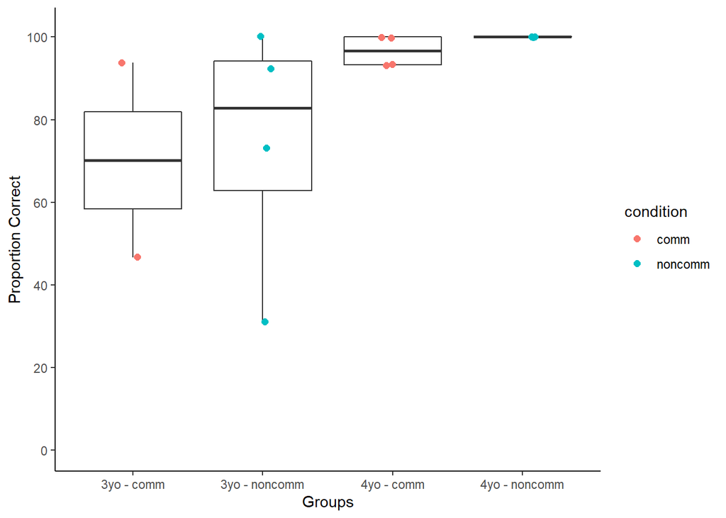

### Performance across trials

Children are tested without feedback. The experimenter merely acknowledges the participant’s choice by saying “thank you”. The plot below presents the proportion of correct choices across all test trials for both age groups and conditions.

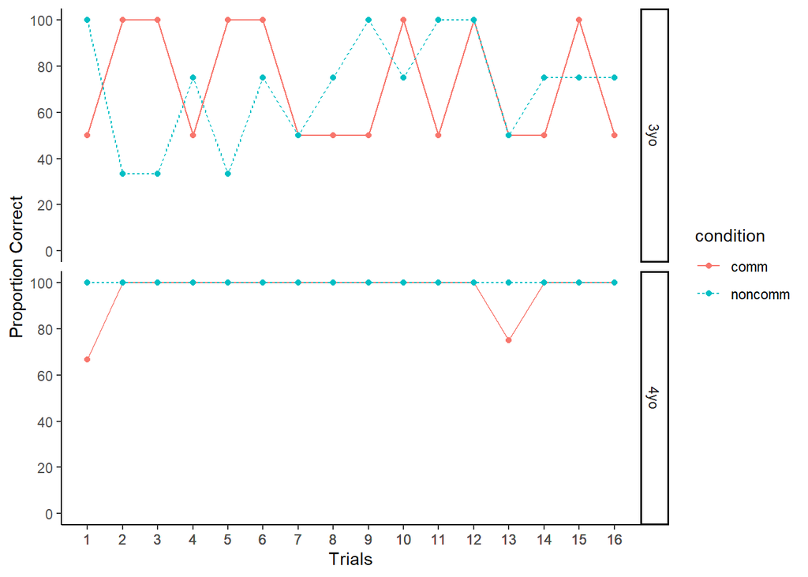

### Performance by items

In each trial, children were presented with a target and distractor shape as well as a cue matching the target shape. The counterbalancing ensures that all shapes occur both as target and distractor. Presentation in trials is counterbalanced. The graph below shows children’s individual performance aggregated for all target shapes. More incorrect choices for a specific target could indicate that a cue is ambiguous.

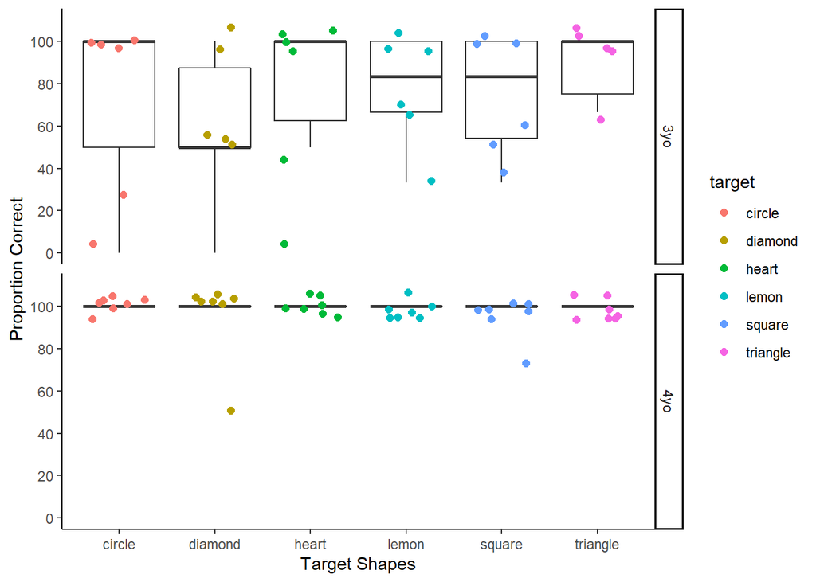

In addition, the plot below shows individual performance across all distractor shapes. More incorrect choices for a specific distractor might indicate that children prefer to select that distractor over any target.

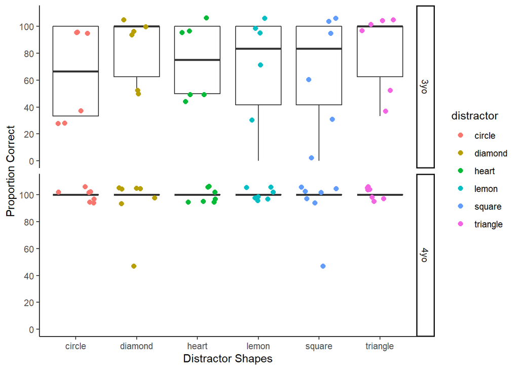

### Testing individual performance against chance

For each individual, we used a binomial test to investigate whether their performance was significantly above chance level (p < 0.05; 50%). The table provides the number and proportion of individuals performing above chance for age experimental group.

| age | condition | N | succesfull | % successful |
| --- | --- | --- | --- | --- |
| 3yo | comm | 2 | 1 | 50 |
| 3yo | noncomm | 4 | 2 | 50 |
| 4yo | comm | 4 | 4 | 100 |
| 4yo | noncomm | 3 | 3 | 100 |

### Full Analysis (GLMM, ANOVA)

We are going to analyze our outcome (correct choice 0/1) in a 2x2 design (condition (comm, noncomm); age (3yo, 4yo) using either a GLMM or ANOVA depending on prior tests on data structure and model stability.

# References

R Core Team (2019). R: A language and environment for statistical computing. R Foundation for Statistical Computing, Vienna, Austria. URL https://www.R-project.org/.

Wickham et al., (2019). Welcome to the tidyverse. Journal of Open Source Software, 4(43), 1686, https://doi.org/10.21105/joss.01686